# What comes first

Maria Khachatryan, Marta Kołczyńska, Filip Kowalski, Jakub Siwiec, Paweł Zawadzki

11/12/2018

### Wikipedia, Google, News

What comes first: interest in a given topic of the general public, specialists, or the news? How do events trigger Google searches, news coverage, and Wikipedia views?

Data sources:  
* Wikipedia page views and edits,  
* Google searches,  
* coverage in the news media and academic pre-print repositories (SSRN and arXiv).

All data are monthly.

### Interest in technology

15 keywords related to internet technology: Facebook, 5G, blockchain, Bitcoin, algorithm, wireless, ethereum, cyberattack, Linux, MIMO, radius, botnet, yang, MINIX, and iSCSI.

Not so exciting: wireless, Linux.  
Very exciting: Bitcoin, cyberattack.

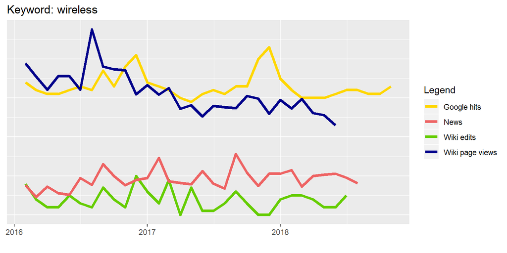

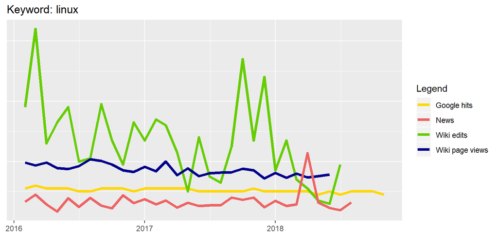

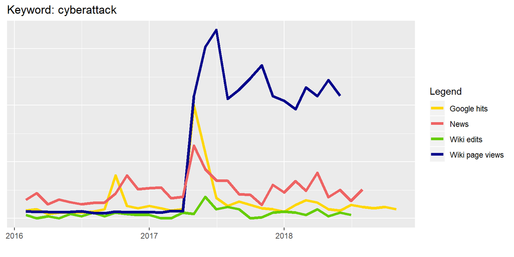

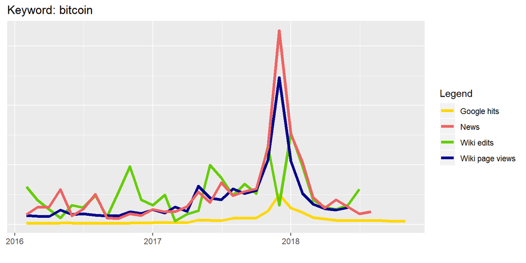

### Cross-correlations

We have started to analyze the temporal correlation of public and media interest in specific topics quantitatively with cross-correlations between the time series. The graph below shows the cross-correlation for Google hits and news occurrences for the keyword “cyberattack”. It seems that Google hits and news occurrences are correlated contemporaneously, or Google hits precede news occurrences by about one month (positive correlation for the lag of -1).

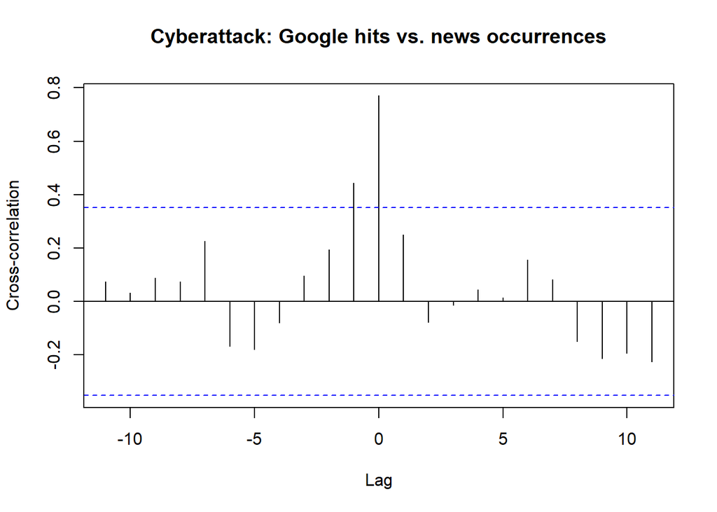

### News coverage *versus* Wikipedia page views

X axis: cumulative monthly news coverage,  
Y axis: cumulative monthly Wikipedia page views,  
Size of bubble: cumulative monthly Wikipedia edits.

[interactive chart not shown]